# 14-01 데이터 분석 예제 (1. USA.gov 데이터)

### 1.USA.gov 데이터

- 2011년 URL 축약 서비스인 Bit.ly는 미국 정부 웹사이트인 USA.gov와 제휴하여 .gov나 .mil로 끝나는 URL을 축약한 사용자들에 대한 익명 정보를 제공
- 2011년에는 실시간 피드뿐 아니라 매 시간마다 스냅샷을 텍스트 파일로 내려받을 수 있었다

```python
import json
```

```python
path = 'datasets/bitly_usagov/example.txt'
```

```python
records = [json.loads(line) for line in open(path, encoding = 'UTF-8')]
```

```python
records[0]
```

```
{'a': 'Mozilla/5.0 (Windows NT 6.1; WOW64) AppleWebKit/535.11 (KHTML, like Gecko) Chrome/17.0.963.78 Safari/535.11',
 'c': 'US',
 'nk': 1,
 'tz': 'America/New_York',
 'gr': 'MA',
 'g': 'A6qOVH',
 'h': 'wfLQtf',
 'l': 'orofrog',
 'al': 'en-US,en;q=0.8',
 'hh': '1.usa.gov',
 'r': 'http://www.facebook.com/l/7AQEFzjSi/1.usa.gov/wfLQtf',
 'u': 'http://www.ncbi.nlm.nih.gov/pubmed/22415991',
 't': 1331923247,
 'hc': 1331822918,
 'cy': 'Danvers',
 'll': [42.576698, -70.954903]}
```

### 순수 파이썬으로 표준시간대 세어보기

```python
time_zones = [rec['tz'] for rec in records if 'tz' in rec]
```

```python
time_zones[:10]
```

```
['America/New_York',
 'America/Denver',
 'America/New_York',
 'America/Sao_Paulo',
 'America/New_York',
 'America/New_York',
 'Europe/Warsaw',
 '',
 '',
 '']
```

- 상위 10개의 표준시간대를 보면 그중 몇 개는 비어 있어서 알 수 없다.
- 비어 있는 필드를 제거할 수도 있지만 일단은 그냥 두고 표준시간대를 셈
- 개수를 새는 함수 작성

```python
def get_counts(sequence):
    counts = {}
    for x in sequence:
        if x in counts:
            counts[x] += 1
        else:
            counts[x] = 1
    return counts
```

```python
from collections import defaultdict

def get_counts2(sequence):
    counts = defaultdict(int) # 값이 0으로 초기화
    for x in sequence:
        counts[x] += 1
    return counts
```

- **딕셔너리의 값 별 개수**

```python
counts = get_counts(time_zones)
```

```python
counts['America/New_York']
```

```
1251
```

```python
len(time_zones)
```

```
3440
```

- **가장 많이 등장하는 상위 10개의 표준시간대 확인**

```python
def top_counts(count_dict, n=10):
    value_key_pairs = [(count, tz) for tz, count in count_dict.items()]
    value_key_pairs.sort()
    return value_key_pairs[-n:]
```

```python
top_counts(counts)
```

```
[(33, 'America/Sao_Paulo'),
 (35, 'Europe/Madrid'),
 (36, 'Pacific/Honolulu'),
 (37, 'Asia/Tokyo'),
 (74, 'Europe/London'),
 (191, 'America/Denver'),
 (382, 'America/Los_Angeles'),
 (400, 'America/Chicago'),
 (521, ''),
 (1251, 'America/New_York')]
```

- **파이썬 표준 라이브러리 collections.Counter 클래스를 이용하여 지금까지의 작업을 편리하게**

```python
from collections import Counter
```

### `Counter()` : 값 별 개수를 포함하는 딕셔너리 반환

### `.most_common(n)` : 딕셔너리에서 가장 많이 등장하는 상위 10개

```python
counts = Counter(time_zones)
```

```python
counts.most_common(10)
```

```
[('America/New_York', 1251),
 ('', 521),
 ('America/Chicago', 400),
 ('America/Los_Angeles', 382),
 ('America/Denver', 191),
 ('Europe/London', 74),
 ('Asia/Tokyo', 37),
 ('Pacific/Honolulu', 36),
 ('Europe/Madrid', 35),
 ('America/Sao_Paulo', 33)]
```

### pandas로 표준 시간대 세어보기

```python
import pandas as pd
import numpy as np
import matplotlib.pyplot as plt
```

```python
frame = pd.DataFrame(records)
frame.info()
```

```
<class 'pandas.core.frame.DataFrame'>
RangeIndex: 3560 entries, 0 to 3559
Data columns (total 18 columns):
 #   Column       Non-Null Count  Dtype
---  ------       --------------  -----
 0   a            3440 non-null   object
 1   c            2919 non-null   object
 2   nk           3440 non-null   float64
 3   tz           3440 non-null   object
 4   gr           2919 non-null   object
 5   g            3440 non-null   object
 6   h            3440 non-null   object
 7   l            3440 non-null   object
 8   al           3094 non-null   object
 9   hh           3440 non-null   object
 10  r            3440 non-null   object
 11  u            3440 non-null   object
 12  t            3440 non-null   float64
 13  hc           3440 non-null   float64
 14  cy           2919 non-null   object
 15  ll           2919 non-null   object
 16  _heartbeat_  120 non-null    float64
 17  kw           93 non-null     object
dtypes: float64(4), object(14)
memory usage: 500.8+ KB
```

```python
frame.head()
```

|  | a | c | nk | tz | gr | g | h | l | al | hh | r | u | t | hc | cy | ll | _heartbeat_ | kw |
| --- | --- | --- | --- | --- | --- | --- | --- | --- | --- | --- | --- | --- | --- | --- | --- | --- | --- | --- |
| 0 | Mozilla/5.0 (Windows NT 6.1; WOW64) AppleWebKi... | US | 1.0 | America/New_York | MA | A6qOVH | wfLQtf | orofrog | en-US,en;q=0.8 | 1.usa.gov | http://www.facebook.com/l/7AQEFzjSi/1.usa.gov/... | http://www.ncbi.nlm.nih.gov/pubmed/22415991 | 1.331923e+09 | 1.331823e+09 | Danvers | [42.576698, -70.954903] | NaN | NaN |
| 1 | GoogleMaps/RochesterNY | US | 0.0 | America/Denver | UT | mwszkS | mwszkS | bitly | NaN | j.mp | http://www.AwareMap.com/ | http://www.monroecounty.gov/etc/911/rss.php | 1.331923e+09 | 1.308262e+09 | Provo | [40.218102, -111.613297] | NaN | NaN |
| 2 | Mozilla/4.0 (compatible; MSIE 8.0; Windows NT ... | US | 1.0 | America/New_York | DC | xxr3Qb | xxr3Qb | bitly | en-US | 1.usa.gov | http://t.co/03elZC4Q | http://boxer.senate.gov/en/press/releases/0316... | 1.331923e+09 | 1.331920e+09 | Washington | [38.9007, -77.043098] | NaN | NaN |
| 3 | Mozilla/5.0 (Macintosh; Intel Mac OS X 10_6_8)... | BR | 0.0 | America/Sao_Paulo | 27 | zCaLwp | zUtuOu | alelex88 | pt-br | 1.usa.gov | direct | http://apod.nasa.gov/apod/ap120312.html | 1.331923e+09 | 1.331923e+09 | Braz | [-23.549999, -46.616699] | NaN | NaN |
| 4 | Mozilla/5.0 (Windows NT 6.1; WOW64) AppleWebKi... | US | 0.0 | America/New_York | MA | 9b6kNl | 9b6kNl | bitly | en-US,en;q=0.8 | bit.ly | http://www.shrewsbury-ma.gov/selco/ | http://www.shrewsbury-ma.gov/egov/gallery/1341... | 1.331923e+09 | 1.273672e+09 | Shrewsbury | [42.286499, -71.714699] | NaN | NaN |

```python
frame['tz'].head()
```

```
0     America/New_York
1       America/Denver
2     America/New_York
3    America/Sao_Paulo
4     America/New_York
Name: tz, dtype: object
```

```python
tz_counts = frame['tz'].value_counts()
```

```python
tz_counts[:10]
```

```
America/New_York       1251
                        521
America/Chicago         400
America/Los_Angeles     382
America/Denver          191
Europe/London            74
Asia/Tokyo               37
Pacific/Honolulu         36
Europe/Madrid            35
America/Sao_Paulo        33
Name: tz, dtype: int64
```

- **결측치를 'Missing'으로 대체**
- **비어있는 값을 'Unknown'으로 대체**

```python
clean_tz = frame['tz'].fillna('Missing')
```

```python
clean_tz[clean_tz == ''] = 'Unknown'
```

```python
tz_counts = clean_tz.value_counts()
```

```python
tz_counts[:10]
```

```
America/New_York       1251
Unknown                 521
America/Chicago         400
America/Los_Angeles     382
America/Denver          191
Missing                 120
Europe/London            74
Asia/Tokyo               37
Pacific/Honolulu         36
Europe/Madrid            35
Name: tz, dtype: int64
```

### 데이터 시각화

```python
import seaborn as sns
```

```python
subset = tz_counts[:10]
```

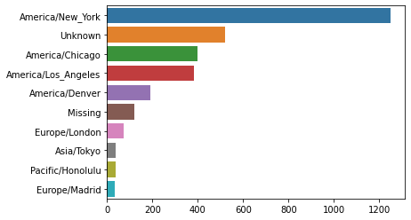

```python
sns.barplot(x = subset.values, y = subset.index)
plt.show()
```

### 표준시간대 순위표를 윈도우 사용자와, 비윈도우 사용자 그룹으로 분리

#### 'a'열에는 URL 단축을 실행하는 브라우저, 단말기, 애플리케이션에 대한 정보 (User Agent 문자열)가 들어있다.

```python
frame['a'][1], frame['a'][50], frame['a'][51]
```

```
('GoogleMaps/RochesterNY',
 'Mozilla/5.0 (Windows NT 5.1; rv:10.0.2) Gecko/20100101 Firefox/10.0.2',
 'Mozilla/5.0 (Linux; U; Android 2.2.2; en-us; LG-P925/V10e Build/FRG83G) AppleWebKit/533.1 (KHTML, like Gecko) Version/4.0 Mobile Safari/533.1')
```

- **'a'열의 문자열을 띄어쓰기를 기준으로 분리하고, 첫 번째 원소만 추출**

```python
results = pd.Series([x.split()[0] for x in frame.a.dropna()])
```

```python
results.head()
```

```
0               Mozilla/5.0
1    GoogleMaps/RochesterNY
2               Mozilla/4.0
3               Mozilla/5.0
4               Mozilla/5.0
dtype: object
```

```python
results.value_counts().head(8)
```

```
Mozilla/5.0                 2594
Mozilla/4.0                  601
GoogleMaps/RochesterNY       121
Opera/9.80                    34
TEST_INTERNET_AGENT           24
GoogleProducer                21
Mozilla/6.0                    5
BlackBerry8520/5.0.0.681       4
dtype: int64
```

- **agent 문자열이 'Windows'를 포함하면 윈도우 사용자**
- **agent 값이 없는 데이터는 제외**

```python
cframe = frame[frame.a.notnull()]
```

- **각 행이 'Windows'를 포함하는지 확인**

```python
cframe['os'] = np.where(cframe['a'].str.contains('Windows'),
                        'Windows', 'Not Windows')
cframe['os'][:5]
```

```
0        Windows
1    Not Windows
2        Windows
3    Not Windows
4        Windows
Name: os, dtype: object
```

- **표준시간대와 운영체제를 기준으로 데이터를 그룹핑**

```python
by_tz_os = cframe.groupby(['tz', 'os'])
```

```python
agg_counts = by_tz_os.size().unstack().fillna(0)
agg_counts.head()
```

| os tz | Not Windows | Windows |
| --- | --- | --- |
|  | 245.0 | 276.0 |
| Africa/Cairo | 0.0 | 3.0 |
| Africa/Casablanca | 0.0 | 1.0 |
| Africa/Ceuta | 0.0 | 2.0 |
| Africa/Johannesburg | 0.0 | 1.0 |

- **전체 표준시간대의 순위 계산** ### `.argsort()`

```python
indexer = agg_counts.sum(1).argsort()
indexer.head()
```

```
tz
                       24
Africa/Cairo           20
Africa/Casablanca      21
Africa/Ceuta           92
Africa/Johannesburg    87
dtype: int64
```

- **agg_counts에 take를 사용해서 행을 정렬된 순서 그대로 선택하고, 마지막 10개 행 (가장 큰 값)만 잘라냄**

```python
count_subset = agg_counts.take(indexer[-10:])
count_subset.head(10)
```

| os tz | Not Windows | Windows |
| --- | --- | --- |
| America/Sao_Paulo | 13.0 | 20.0 |
| Europe/Madrid | 16.0 | 19.0 |
| Pacific/Honolulu | 0.0 | 36.0 |
| Asia/Tokyo | 2.0 | 35.0 |
| Europe/London | 43.0 | 31.0 |
| America/Denver | 132.0 | 59.0 |
| America/Los_Angeles | 130.0 | 252.0 |
| America/Chicago | 115.0 | 285.0 |
|  | 245.0 | 276.0 |
| America/New_York | 339.0 | 912.0 |

### 중첩 막대그래프 생성

```python
count_subset.stack()
```

```
tz                   os
America/Sao_Paulo    Not Windows     13.0
                     Windows         20.0
Europe/Madrid        Not Windows     16.0
                     Windows         19.0
Pacific/Honolulu     Not Windows      0.0
                     Windows         36.0
Asia/Tokyo           Not Windows      2.0
                     Windows         35.0
Europe/London        Not Windows     43.0
                     Windows         31.0
America/Denver       Not Windows    132.0
                     Windows         59.0
America/Los_Angeles  Not Windows    130.0
                     Windows        252.0
America/Chicago      Not Windows    115.0
                     Windows        285.0
                     Not Windows    245.0
                     Windows        276.0
America/New_York     Not Windows    339.0
                     Windows        912.0
dtype: float64
```

```python
count_subset = count_subset.stack()
count_subset.name = 'total'
```

```python
count_subset = count_subset.reset_index()
count_subset.head()
```

|  | tz | os | total |
| --- | --- | --- | --- |
| 0 | America/Sao_Paulo | Not Windows | 13.0 |
| 1 | America/Sao_Paulo | Windows | 20.0 |
| 2 | Europe/Madrid | Not Windows | 16.0 |
| 3 | Europe/Madrid | Windows | 19.0 |
| 4 | Pacific/Honolulu | Not Windows | 0.0 |

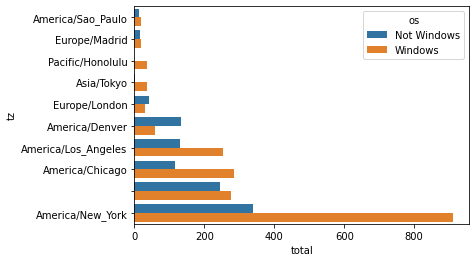

```python
plt.figure()
sns.barplot(x = 'total', y = 'tz',
            hue = 'os',  data = count_subset)
plt.show()
```

- **각 행에서 총합을 1로 정규화한 뒤 그래프 재생성**

```python
def norm_total(group):
    group['normed_total'] = group.total / group.total.sum()
    return group
```

```python
results = count_subset.groupby('tz').apply(norm_total)
```

```python
results.head()
```

|  | tz | os | total | normed_total |
| --- | --- | --- | --- | --- |
| 0 | America/Sao_Paulo | Not Windows | 13.0 | 0.393939 |
| 1 | America/Sao_Paulo | Windows | 20.0 | 0.606061 |
| 2 | Europe/Madrid | Not Windows | 16.0 | 0.457143 |
| 3 | Europe/Madrid | Windows | 19.0 | 0.542857 |
| 4 | Pacific/Honolulu | Not Windows | 0.0 | 0.000000 |

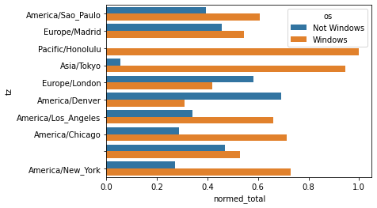

```python
plt.figure()
sns.barplot(x = 'normed_total', y = 'tz',
            hue = 'os',  data = results)
plt.show()
```

- groupby와 transform 메서드를 이용하여 정규합 계산을 더 효율적으로 할 수 있다.

```python
g = count_subset.groupby('tz')
results2 = count_subset.total / g.total.transform('sum')
results2.head()
```

```
0    0.393939
1    0.606061
2    0.457143
3    0.542857
4    0.000000
Name: total, dtype: float64
```